# Introduction

Allan

2023-06-14

# 1 Exectutive Summary

**Approach and Purpose** Master thesis, internship oriented Different subject Actual and related to my country

**Analysis and Data Insights** Sissgrid comprend ou est produite et consommée l’energie Comment le réseau marche et ses complexité. Production and consumption all over the country Different level of aggregation Seasonity

**Recommendation and Suggestions** Forecast and riks

# 2 Introduction

## 2.1 Electricity

L’electricty, au coeur des débats.

“Une pénurie d’énergie l’hiver prochain: tel est le scénario que nous devons éviter par tous les moyens. Une telle situation serait dévastatrice pour l’économie. Dans le dossier «Sur le front de l’énergie», economiesuisse commente l’actualité et évalue les nouveaux développements sous l’angle économique.” selon [l’economiesuisse](https://www.economiesuisse.ch/fr/articles/energieticker-f)

Changement des mentalités

Guerre Ukraine et dépendance à l’étranger La situation est complexe. De manière générale, la Suisse produit davantage d’électricité qu’elle n’en consomme. Pourtant, il est impossible de se passer des importations venues des pays voisins. Cette situation est due aux fluctuations saisonnières dans la production et la consommation d’électricité, et du fait qu’il est toujours très difficile de la stocker. [ici](https://www.rts.ch/info/suisse/13187401-simonetta-sommaruga-la-suisse-a-trop-mise-sur-limportation-delectricite.html)

Climat et vert = transition écologique et sortie du nucléaire

QUEL EST LE MODE DE PRODUCTION LE MOINS CHER? Les technologies à faibles émissions telles que l’éolien, l’hydraulique, le solaire et le nucléaire présentent généralement le meilleur rapport coût/bénéfice pour développer la production d’électricité. La question de savoir quelle technologie permet d’accroître la sécurité d’approvisionnement est extrêmement complexe et doit être examinée au cas par cas. Le monde politique devrait se concentrer sur la création de conditions-cadre favorables et sur la garantie d’un bon rapport coût-efficacité, et non sur la promotion de technologies spécifiques. Pour en savoir plus, nous vous proposons de lire ce blog.

## 2.2 Swiss Grid

**Production** L’entreprise est créée en janvier 2005 par les grandes entreprises d’interconnexion suisses. L’infrastructure doit parfaitement fonctionner, il convient de gérer en permanence les flux d’électricité et de collaborer étroitement avec les partenaires afin que le réseau de transport soit stable et sûr. Swissgrid se charge non seulement de transporter l’énergie électrique, mais également d’assurer un approvisionnement sûr en électricité grâce à ses prestations de services système.

**Exploitation du réseau** Swissgrid ne produit pas d’électricité, mais transporte l’électricité produite par les centrales électriques vers les centres de consommation via le réseau de transport. Les exploitants de centrales aident Swissgrid à garantir la stabilité du réseau en fournissant de l’énergie de réglage. Celle-ci représente une réserve à laquelle Swissgrid recourt en cas de déséquilibre entre la production et la consommation. Si la consommation d’électricité augmente, Swissgrid leur demande d’injecter davantage d’énergie dans le réseau. Si cette dernière diminue, moins d’énergie sera injectée.

**Développement du marché** Swissgrid n’investit pas uniquement dans l’exploitation et la modernisation du réseau de transport afin de garantir la sécurité du système, mais également dans le développement du marché. En rendant plus efficaces les appels d’offres pour l’acquisition de réserves de réglage en Suisse et à l’étranger, Swissgrid peut faire appel à plusieurs fournisseurs et réduire ainsi ses coûts d’acquisition. En outre, Swissgrid développe des solutions de produits innovantes et des nouveaux mécanismes de prix afin de permettre à certains fournisseurs, comme des centrales hydroélectriques, de mieux commercialiser leur grande flexibilité et de pouvoir utiliser de nouvelles technologies telles que des batteries.

**Maintenance et entretien** Swissgrid inspecte et entretient les pylônes, les lignes, les sous-stations ainsi que les postes de couplage et les remet en état, le cas échéant, afin de pouvoir exploiter les installations en toute sécurité. Les responsables d’installation, qui sont répartis sur sept sites, se chargent de cette tâche.

**Infrastructure** Swissgrid est responsable de la planification, du remplacement et de l’extension de toute l’infrastructure du réseau de transport. C’est une tâche ardue, étant donné qu’il existe déjà des congestions à l’heure actuelle, que de nouvelles centrales électriques sont raccordées au réseau et que la dynamique sur les marchés de l’électricité ne cesse de croître. Il convient donc de développer le réseau de transport, ce qui n’implique pas nécessairement la construction de nouvelles lignes, mais plutôt la modernisation ciblée aussi bien que le démantèlement de certaines parties du réseau.

**Interconnexion** La Suisse fait partie intégrante du réseau interconnecté européen. Elle est tributaire de cette interconnexion, notamment afin d’éliminer des congestions en hiver, par exemple. La collaboration internationale permet également de compenser des défaillances de centrales électriques ou la surproduction. Inversement, la Suisse, qui est un pays de transit et accumule une grande quantité d’énergie grâce à ses centrales de pompage-turbinage, joue un rôle important au sein du réseau interconnecté européen.

**Consommation** Aucun consommateur n’est directement raccordé au réseau de transport, à l’exception des Chemins de fer fédéraux. Les consommateurs jouent toutefois un rôle important en ce qui concerne la stabilité du réseau. Si un déséquilibre menace de se produire, Swissgrid demande aux entrepôts frigorifiques ou aux usines d’incinération des ordures ménagères de réduire leur consommation d’énergie, par exemple.

**Postes de couplage** Les postes de couplage placés dans les sous-stations constituent des nœuds entre les lignes. Dans certaines installations, l’énergie est transformée et transmise à différents niveaux de réseau. En outre, les centres de conduite du réseau de Swissgrid déconnectent et raccordent des lignes dans les postes de couplage au moyen de manœuvres de couplage et dirigent ainsi les flux d’électricité.

**Niveaux de réseau** Afin que les consommateurs finaux puissent utiliser l’énergie produite par les centrales électriques, la tension est réduite à 400 et 230 volts par le biais de sept niveaux de réseau. Font partie de ces niveaux les niveaux très haute tension, haute tension, moyenne tension et basse tension ainsi que trois niveaux de transformation reliant ces dernières.

**Réseau de transport** Le réseau de transport suisse comporte 6700 kilomètres de lignes, 12’000 pylônes, 125 sous-stations avec 146 postes de couplage ainsi que 41 liaisons avec l’étranger. Il se compose de lignes à 380 kilovolt et 220 kilovolt. Alors que les lignes à 380 kilovolt sont majoritairement utilisées pour l’importation et l’exportation d’électricité, les grandes centrales électriques suisses injectent principalement leur énergie sur le réseau 220 kilovolt. Des tensions de l’ordre du kilovolt sont nécessaires sur le réseau de transport afin de pouvoir transporter l’énergie sur de longues distances avec le moins de pertes possible.

## 2.3 The Network

Il n’est pas visible, mais il est pourtant toujours présent: le courant. Nous l’utilisons naturellement et souvent de manière inconsciente. Le matin lorsque nous allumons la lumière, mettons la machine à café en marche ou quand nous écoutons la radio. Cette transformation est un véritable défi. Avoir la bonne quantité de courant sur le réseau en est un autre. À savoir livrer en tout temps la même quantité d’électricité que celle qui est utilisée au même moment. En effet, la consommation d’énergie et la production d’énergie doivent toujours être équilibrées. Swissgrid s’en charge. 24 heures sur 24. 7 jours sur 7. Afin que le réseau de transport puisse fonctionner, il est indispensable de maintenir un équilibre permanent entre production et consommation d’énergie. Cet équilibre garantit l’exploitation sûre et fiable du réseau électrique à une fréquence constante de 50 Hertz. Toutefois, le réseau de transport suisse peut connaître des fluctuations et des charges imprévues. Dans ce cas, les opérateurs doivent agir: où faut-il injecter davantage d’énergie afin que le réseau soit à nouveau équilibré et que la fréquence du réseau retrouve sa valeur de consigne de 50 Hertz? L’électricité ne pouvant pas être stockée sur le réseau de transport, il est nécessaire que l’injection de courant et le soutirage soient toujours égaux. En d’autres termes, la production et la consommation d’énergie doivent toujours être à l’équilibre. C’est cet équilibre qui garantit la sécurité et la stabilité de l’exploitation du réseau à une fréquence constante de 50 Hertz; il n’y a pas que le réseau de transport suisse qui est exploité à cette fréquence: c’est aussi le cas de tout le réseau interconnecté européen. De concert avec les autres gestionnaires de réseau de transport, Swissgrid veille à ce que cette fréquence puisse être respectée en permanence sur le réseau interconnecté. En Suisse, le courant est disponible en permanence. 24 heures sur 24, 365 jours par an. Mais ce n’est pas de toute évidence: notamment en hiver, les producteurs d’électricité font face à des défis particuliers. Le besoin en énergie augmente en cas de chute de neige, de verglas et de grand froid. Le problème: la production d’électricité en Suisse ne peut pas couvrir ce besoin supplémentaire en électricité. C’est la raison pour laquelle la Suisse est tributaire d’importations en hiver. En cas de fluctuations imprévues, les opérateurs des centres de conduite du réseau ont recours à l’énergie de réglage. Il s’agit d’énergie que les centrales électriques mettent en réserve pour Swissgrid et qui peut être utilisée si nécessaire. Les centrales électriques peuvent augmenter ou diminuer leur puissance à court terme, compensant ainsi l’énergie électrique manquante ou excédentaire. Sur le réseau interconnecté européen, l’équilibrage entre production et consommation s’effectue via un processus en trois étapes: la première étape consiste à activer l’énergie de réglage primaire. En cas de fluctuations de fréquence, les turbines des centrales électriques dans toute l’Europe réagissent en augmentant ou diminuant leur puissance. Au bout de quelques minutes (5min environ), le réglage primaire est remplacé par le réglage secondaire. Ce dernier est réalisé par les centrales électriques suisses auxquelles Swissgrid envoie un signal automatique. Au bout d’un quart d’heure, les opérateurs utilisent manuellement l’énergie de réglage tertiaire. Ils donnent à certaines centrales électriques de Suisse ou de l’étranger l’instruction d’injecter plus ou moins d’énergie dans le réseau. Afin que l’équilibre du réseau puisse être assuré à tout moment, il est indispensable de procéder à une planification minutieuse avec les centrales électriques et les négociants d’électricité. Swissgrid est chargée de maintenir constamment le réseau de transport suisse à l’équilibre. C’est pourquoi les centrales électriques et les négociants d’électricité sont également tenus de toujours injecter dans le réseau, c’est-à-dire produire ou acheter, la même quantité d’énergie que celle qu’ils vendent.

Le résaux en quelques chiffres :

Tension de 380 kilovolts et 220 kilovolts

250 000 kilomètres (6x le tour du globe, l’ensemble du résaux électrique)

6700 kilomètres (longueur des lignes du résaux de transport)

12 000 pylônes

147 postes de couplage

41 lignes frontalières

2,5 milliards de francs suisses pour les investissements prévus

## 2.4 Law, limits and regulations

**Champs électromagnétiques** Quand on parle de lignes électriques ou d’appareils électriques, le sujet des rayonnements électromagnétiques et de leurs risques potentiels revient souvent. Ces rayonnements sont à proprement parler des champs électriques et magnétiques. Des valeurs limites nous protègent des effets négatifs pour la santé. Les valeurs limites en Suisse font partie des plus strictes au monde.

La valeur limite d’immissions de 100 microteslas pour les champs magnétiques protège en particulier des atteintes à la santé scientifiquement reconnues. Elle s’applique partout où des personnes pourraient séjourner. La Loi suisse sur la protection de l’environnement exige en outre de protéger également la population des risques pour la santé aujourd’hui non avérés mais envisageables. C’est à cela que sert la valeur limite de l’installation de 1 microtesla. Elle s’applique partout où des personnes séjournent durablement, par exemple dans les salons ou les chambres, les écoles ou les aires de jeux. C’est une des valeurs limites les plus strictes en Europe. Les deux valeurs limites s’appliquent pour la charge maximale d’une ligne.

**Bruit**

Des décharges électriques locales peuvent se produire au niveau des lignes électriques, notamment en cas de conditions météorologiques défavorables, par exemple en cas de pluie, de givre ou de neige mouillée. En électrotechnique, ce phénomène est appelé «décharge coronaire». Il peut générer des bruits décrits comme des grésillements ou des bourdonnements.

Une limite d’émission de 55 décibels dans les zones habitées (45 décibels durant la nuit) est applicable en Suisse et doit impérativement être respectée. Le niveau sonore d’une rue à grande circulation dépasse 80 décibels. Partout où cela est nécessaire, Swissgrid s’efforce de réduire ces effets coronaires par tous les moyens techniques possibles. Dans le cas des lignes souterraines, les bruits dus à l’effet de couronne disparaissent.

**Environnement**

L’étude de l’impact sur l’environnement (EIE) permet, dans le cadre de la procédure d’autorisation, de contrôler si un projet respecte les prescriptions légales sur la protection de l’environnement. Le contrôle se base sur le rapport d’impact sur l’environnement (RIE). En tant que maître d’ouvrage, Swissgrid est responsable de l’élaboration et de la remise des documents du RIE. Toutefois, l’élaboration du RIE est en règle générale confiée à un bureau d’ingénierie indépendant et spécialisé. Différents aspects sont traités dans le rapport, dont le bruit, les rayonnements non ionisants, les eaux, les sols, les décharges désaffectées, les forêts, les biotopes et la végétation, la faune et ses habitats naturels, les paysages, les sites construits ainsi que les monuments historiques et les sites archéologiques.

Le suivi environnemental de la phase de réalisation (SER) traite et pilote les considérations environnementales lors de la construction et assiste la maîtrise d’ouvrage pour une réalisation du projet de construction conforme à la loi et respectueuse de l’environnement.

**Procédures d’autorisation**

Swissgrid est responsable de la planification et de la réalisation des lignes de transport. La procédure d’autorisation et d’approbation de la Confédération comprend six phases qu’il faut impérativement respecter. Celles-ci prennent en considération les demandes des différentes parties prenantes. De nombreux acteurs participent aux discussions. À la fin, ce sont les autorités qui décident dans quel corridor une ligne sera construite et quelle technologie sera employée.

Les 6 étapes en questions :

Préparation Lors de la phase préliminaire, Swissgrid élabore différents corridors de lignes câblées souterraines et de lignes aériennes pour la zone dans laquelle la ligne doit passer, et ce pour chaque projet de réseau. Swissgrid et les cantons concernés par le projet concluent un accord de coordination, qui garantit que les préoccupations des cantons sont prises en compte dès le début de la planification. Les variantes élaborées et la demande d’intégration du projet au plan sectoriel de la Confédération constituent la base pour le début de la procédure d’autorisation.

Plan sectoriel des lignes de transport d’électricité Le PSE est l’instrument de planification et de coordination principal de la Confédération pour l’extension et la construction de nouvelles lignes de transport. La procédure à deux étapes distingue la zone de planification et le corridor d’une nouvelle ligne. Un groupe d’accompagnement mis en place par l’OFEN, composé de représentants de la Confédération, des cantons, des organisations de défense de l’environnement et de Swissgrid, discute des variantes proposées et émet une recommandation. La décision est conditionnée par le Modèle d’évaluation pour lignes de transport de la Confédération. Il tient compte des aspects techniques, de l’aménagement du territoire, de l’environnement et de la rentabilité. Les parties concernées peuvent prendre position dans le cadre d’une consultation publique. Le Conseil fédéral définit la zone de planification, le corridor et la technologie (ligne câblée souterraine ou aérienne) de la future ligne.

Projet de construction Lors de cette phase, Swissgrid élabore un projet de construction concret dans le respect du corridor de planification défini par la Confédération. Le tracé précis de la ligne, les délais et les coûts sont définis, ou des négociations concernant les droits de passage ont lieu. Swissgrid implique une commission consultative pour tenir compte des demandes de la population et d’autres parties prenantes dans la planification du projet. A la fin de cette troisième phase, Swissgrid dépose une demande d’approbation des plans pour le projet de réseau concerné auprès des autorités compétentes.

Procédure d’approbation des plans À la fin de l’étude de projet, Swissgrid dépose la demande de permis de construire auprès de l’Inspection fédérale des installations à courant fort (ESTI). Elle comporte le dossier d’approbation des plans et un rapport d’impact sur l’environnement. Le projet est ensuite mis à l’enquête publique. Les participants et les personnes concernées peuvent désormais faire opposition auprès de l’ESTI. Si l’ESTI ne parvient pas à régler les différends, l’Office fédéral de l’énergie poursuit les négociations. A la fin de cette phase, les autorités accordent le permis de construire à Swissgrid ou édictent des exigences supplémentaires qui doivent être prises en compte dans la planification du projet.

Procédures juridiques Lorsque le permis de construire a été accordé pour le projet de réseau, cette décision peut faire l’objet d’un recours par les autorités, les associations ou les parties directement concernées. Le Tribunal administratif fédéral et le Tribunal fédéral décident alors si les décisions de l’administration fédérale sont légales et si le droit a été correctement appliqué dans le cadre de recours des parties concernées. Si les tribunaux donnent le feu vert, les travaux de construction peuvent commencer. Si le recours est accepté, le projet retourne à la phase d’approbation des plans (phase 4), ou il faut recommencer la procédure de plan sectoriel (phase 2). Ces longues procédures juridiques retardent considérablement les projets de réseau.

Construction Les travaux de construction peuvent commencer lorsque le permis de construire exécutoire a été accordé, les appels d’offres ont été réalisés, les offres comparées et les lots attribués. Les dernières servitudes sont négociées et les contrats correspondants sont conclus. Le projet de réseau prend fin lors de la mise en service de la nouvelle ligne, ou après le démantèlement de lignes existantes devenues inutiles.

Actuellement, il faut compter 15 ans entre le début du projet et la mise en service de la ligne en question. Cependant, des oppositions et des décisions juridiques prises à un stade tardif entraînent fréquemment un retard important des projets, qui peuvent prendre jusqu’à une trentaine d’année.

La modernisation de l’infrastructure de réseau est essentielle à la réussite de la stratégie énergétique de la Confédération. Or, le développement du réseau ne peut pas suivre le rythme de l’évolution des énergies renouvelables. De plus, nous sommes aujourd’hui déjà confrontés à des congestions structurelles dans le réseau de transport. Swissgrid doit demander régulièrement aux exploitants de centrales électriques de restreindre leur production. C’est la raison pour laquelle il est primordial d’accélérer le développement du réseau par des procédures d’autorisation et d’approbation efficaces. Swissgrid a défini tous les projets de réseau indispensables pour un réseau de transport suisse sûr et fiable dans son «Réseau stratégique 2025».

## 2.5 Overview of the network

**Main source of production** L’électricité consommée en Suisse en 2021 provenait à 80% des énergies renouvelables selon [la confédération](https://www.admin.ch/gov/fr/accueil/documentation/communiques.msg-id-90221.html) (production + importation)

Concernant la production uniquement : - central hydraulique (61,5%) 682 centrales hydrauliques - centrales nucléaire (28,9%) - La part des nouvelles énergies renouvelables (énergie solaire, éolienne, biomasse et petite hydraulique, 7.7%) - agents énergétiques fossiles (1.9%) - 29.7% production vs 70.3% importation

L’électricité produite en Suisse est issue à 61,5% de la force hydraulique, à 28,9% de l’énergie nucléaire, à 1,9% des énergies fossiles et à 7,7% environ de nouvelles énergies renouvelables (mix de production suisse 2021. Voir à ce propos: statistique de l’électricité sous le lien ci-après). Mais la Suisse ne consomme pas que de l’électricité d’origine indigène. Il existe un commerce actif avec l’étranger dans le cadre duquel l’électricité est importée et exportée physiquement, indépendamment du négoce des garanties d’origine entre les États. De ce fait, le mix de production suisse ne correspond pas à la composition moyenne de l’électricité livrée (mix des fournisseurs suisses).

Au niveau des mesures prises en charges pour les confédération : - diminuer de 43% la consommation d’énergie par habitants d’ici 2035 par rapport à 2000 - dévolopper au maximum les énergies renouvelables -abandon progressive du nucléaire.

**trend and seasonality**

En Suisse, la consommation d’énergie par habitant baisse, pour sa part, depuis des années: bien que la population ait augmenté de 28,7% entre 1990 et 2020, la consommation d’énergie a diminué de 5,9% au cours de la même période.

**What thrives the consumption**

Different cons and prod around the country. Depend mainly on : density pop, size, activity, landscape.

Seasonality effect for both prod and cons.

## 2.6 My questions

Les risques, se qui régulent le marché, qui sont les principaux consomateurs et producteurs. L’exploitation du réseau de transport est planifiée à long terme. Plus d’un an à l’avance, les opérateurs établissent déjà un premier pronostic sur la situation de réseau attendue dans le centre de conduite du réseau d’Aarau à l’aide d’un modèle de réseau. La planification tient compte des révisions et des réparations des centrales électriques ou des lignes, par exemple. Ainsi, les mises hors service d’éléments du réseau ont des répercussions sur les capacités de transport. Faire un modèle de prévision.

La planification de l’exploitation du réseau est affinée en continu: la situation de réseau attendue est régulièrement recalculée, à savoir un an, un mois, une semaine, deux jours et un jour avant l’exploitation en temps réel.

Peut être intéressant de faire pareil.

# 3 Preliminary Data Anylsis

## 3.1 Overview of the data

We have a total of 65 variables with a total of 487872 observations.

Second, we got data from [gadm](https://gadm.org/) providing maps and spatial data for many countries on 4 different levels. In our project, we will use the data for Switzerland on a Canton level.

## 3.3 Data cleaning and pre-processing

Due to the importance of the number of variables, we have decided to create sub-dataset for every type of Data : - Overall - Cantons - Borders - Foreign - Price

Every DataSet had been transformed into a tsibble, a new data structure that help and support with temporal data. One should look at [this paper](https://arxiv.org/pdf/1901.10257.pdf) for further references. We used the timestamp of 15min to get a better understanding of the data and help us building stronger models and forecast.

Here is quick overlook of our dataset :

[output not shown]

A new tidy data structure to support exploration and modeling of temporal data

# 4 EDA

## 4.1 Quick Visualization

Daily Consumption in Million

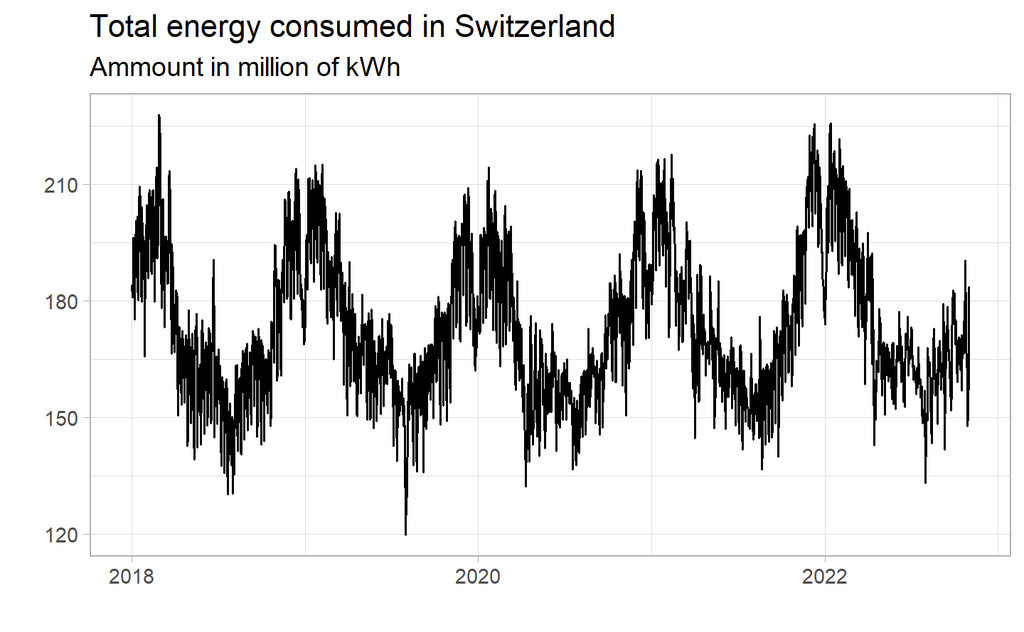

-> Strong seasonlity, no obvious trend -> seems to have diffent level of seasonility but hard to get due to the scope

Dayly Production

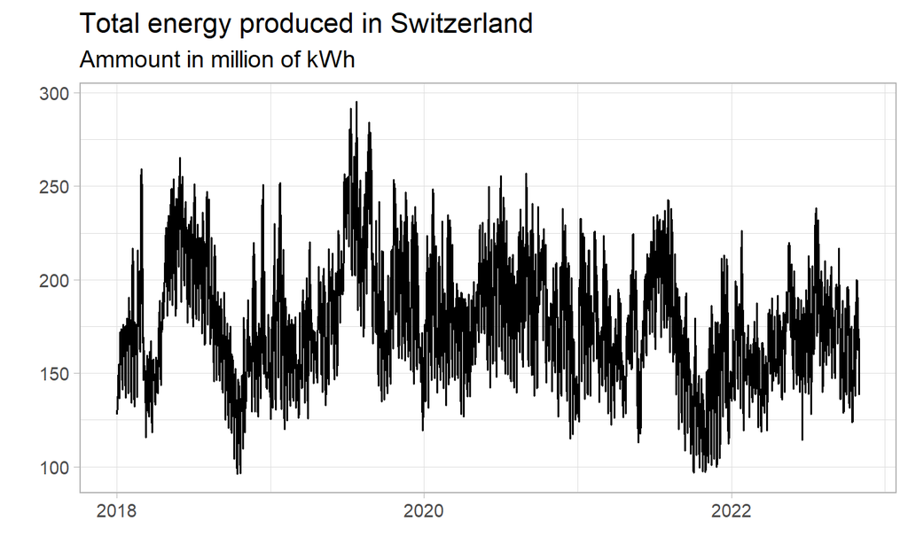

-> also Strong seasonlity, no obvious trend but more messy -> seems to have diffent level of seasonility but hard to get due to the scope

Zoom in to see the monthly seasonality

Monthly

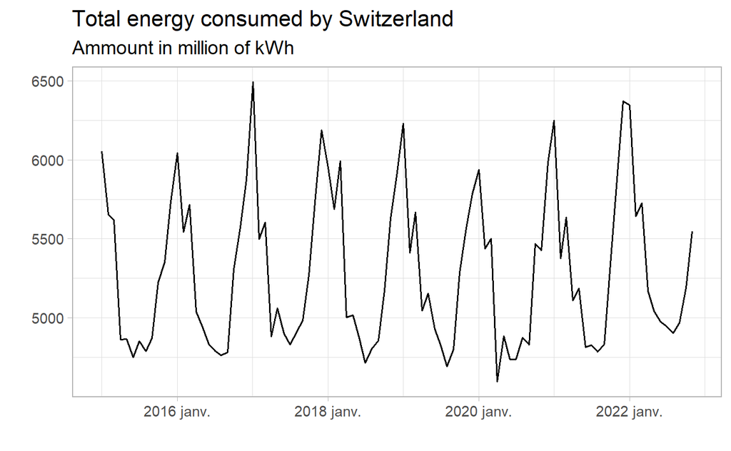

Strong seasonality, no trend, peaks in Winter, lowest in sommer

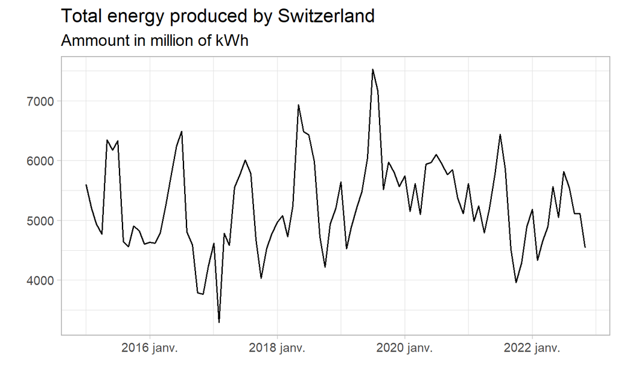

opposite of consumption, Strong seasonality, no trend, peaks in Summer, lowest in winter

## 4.2 Seasonality

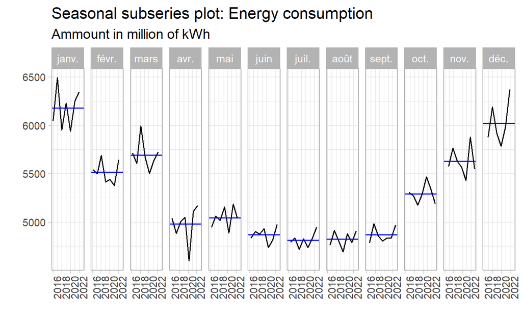

Better view that confirmed what we previous said for consumption

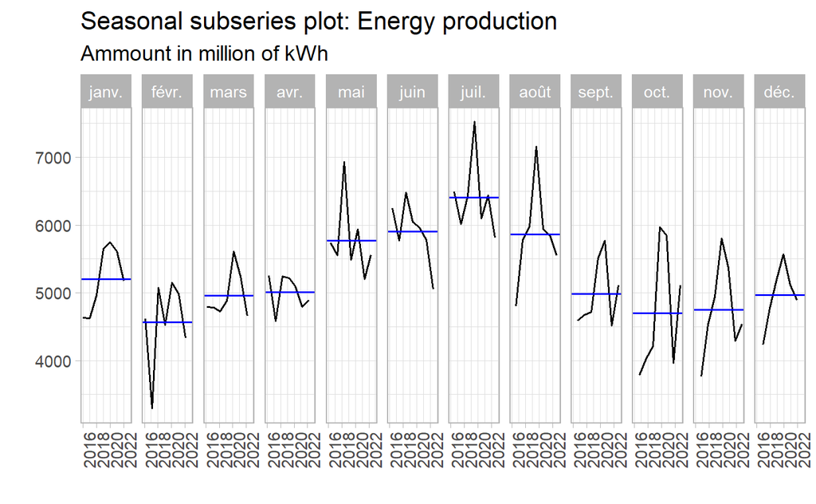

Better view that confirmed what we previous said for prodcution

Zoom in to see the weekly seasonality

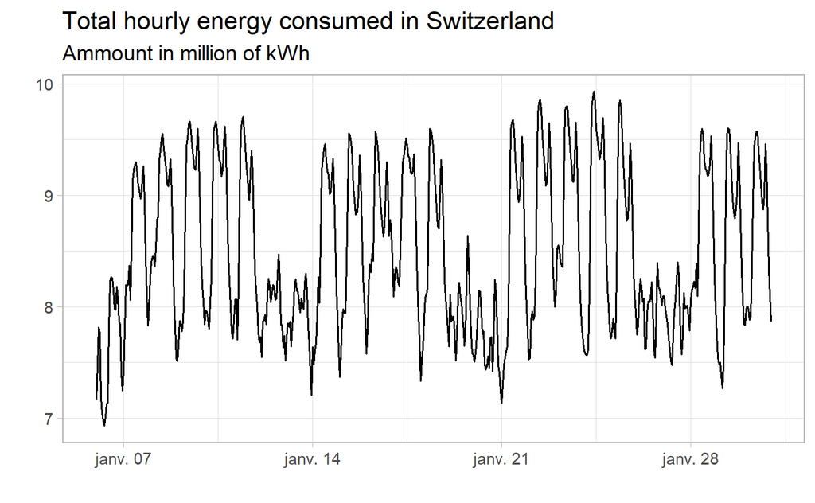

We can see here both weelky and daily seasonlaty : With peaks during days (morning and end of afternoon) and during week with higher volume on weekday (no significant difference among days themselves)

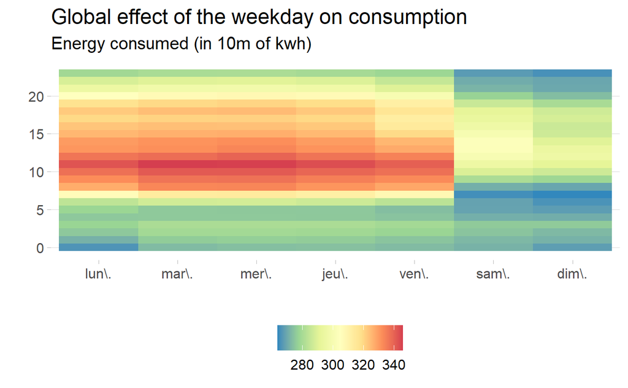

Trend is generalized through the whole period, peaks around noon

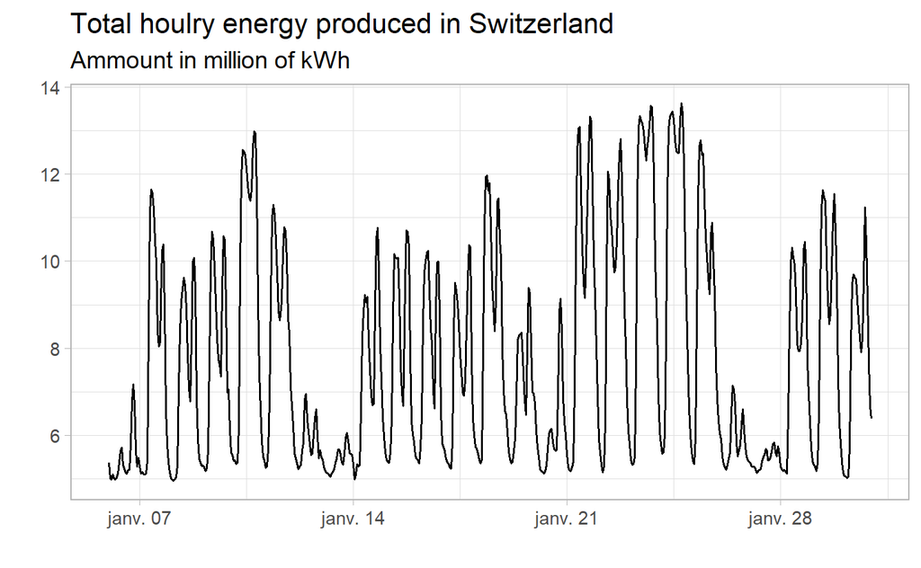

same conclusion as consumption

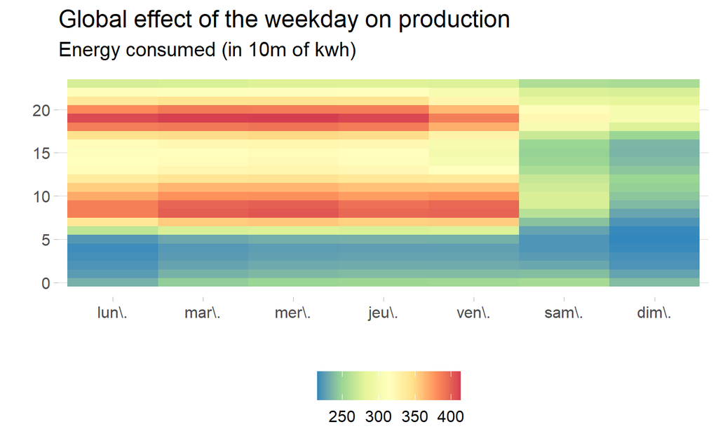

## 4.3 STL Decomp

We can now build the stl decomp with additive paramater due to no change over time in the seasonlity :

We reduce the scope to a year the have a better a view of the data, we have shown that seasonality was constant over the year. also show us the weekly seasonality

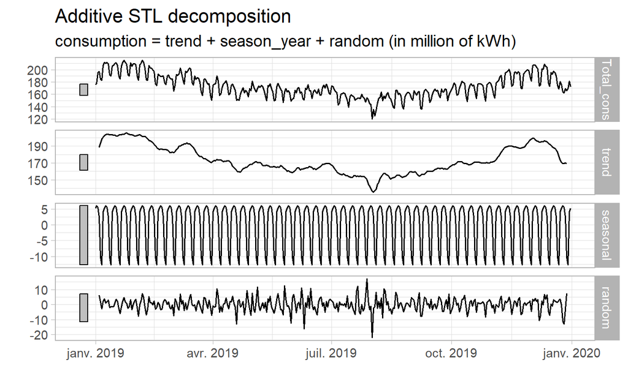

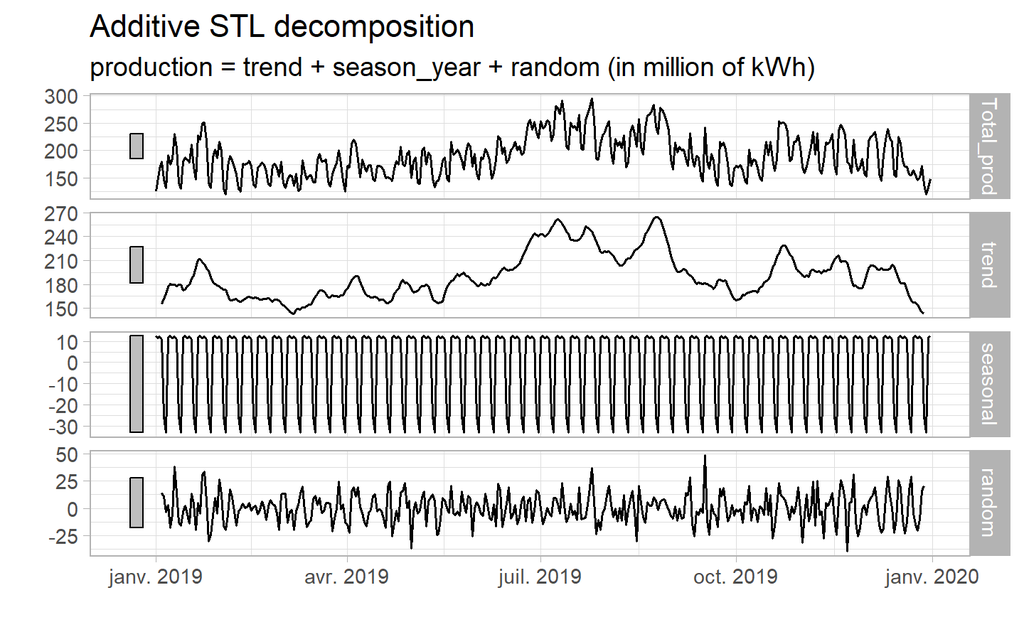

Same for production

[figure not shown]

Monthly seasonality for cons

[figure not shown]

Monthly seasonality for prod

## 4.4 Residuals

Let’s have a look at the residuals :

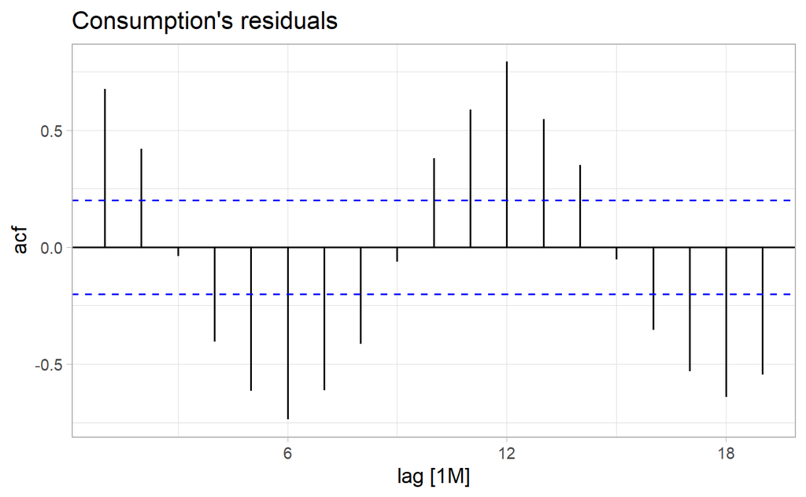

for cons

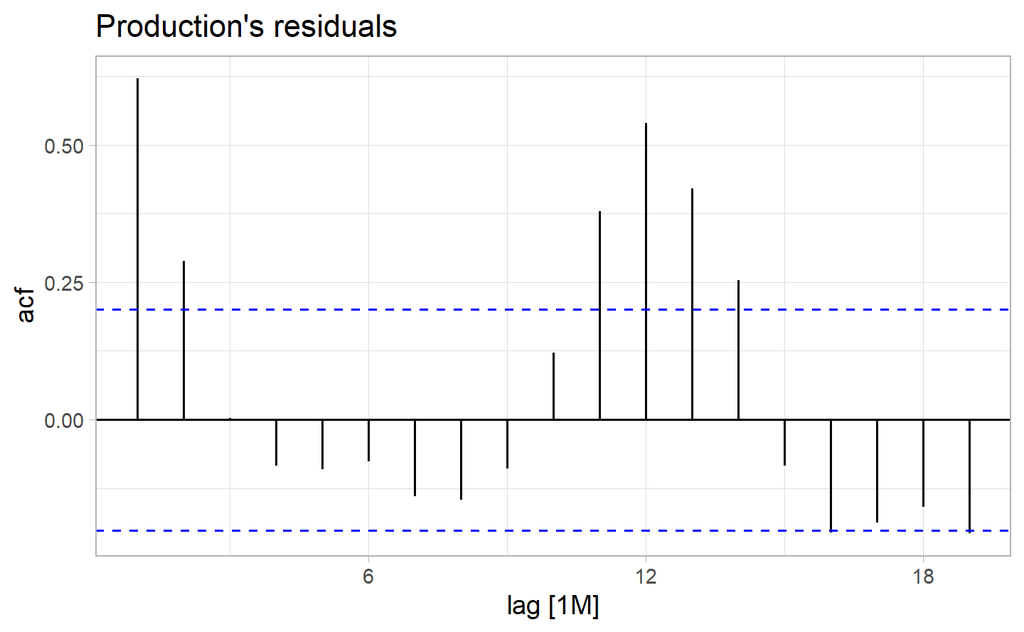

for prod

## 4.5 Second and Tertiary control

Positive and Negative Secondary control with trend

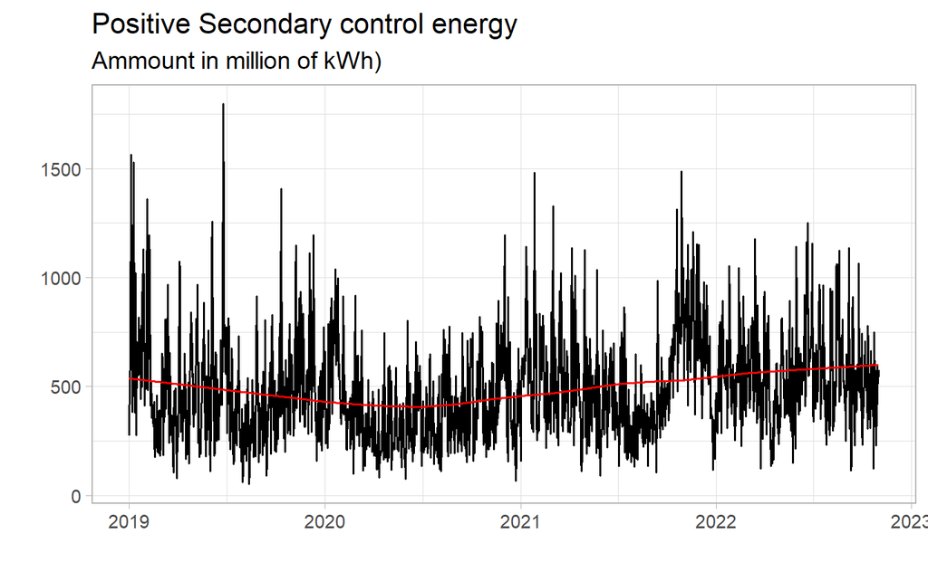

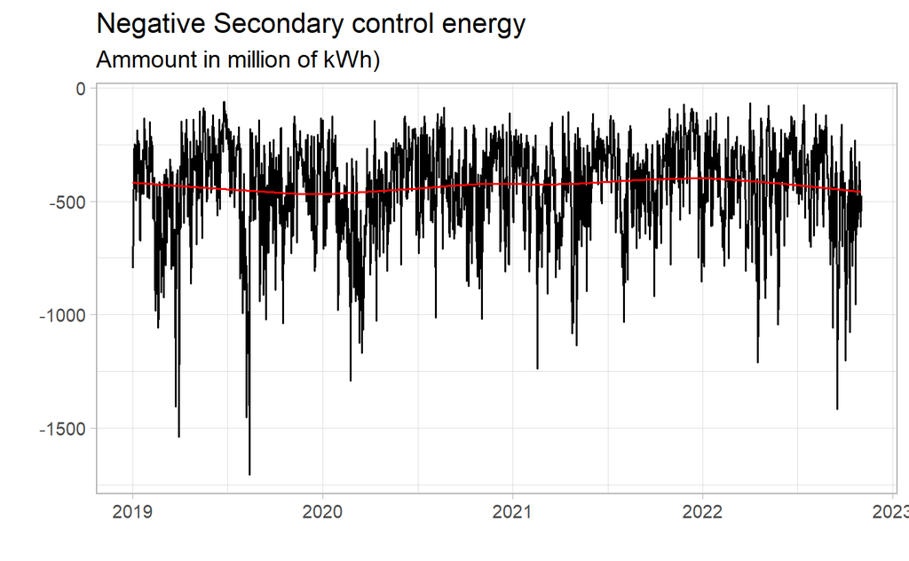

Positive and Negative Tertiary control with trend

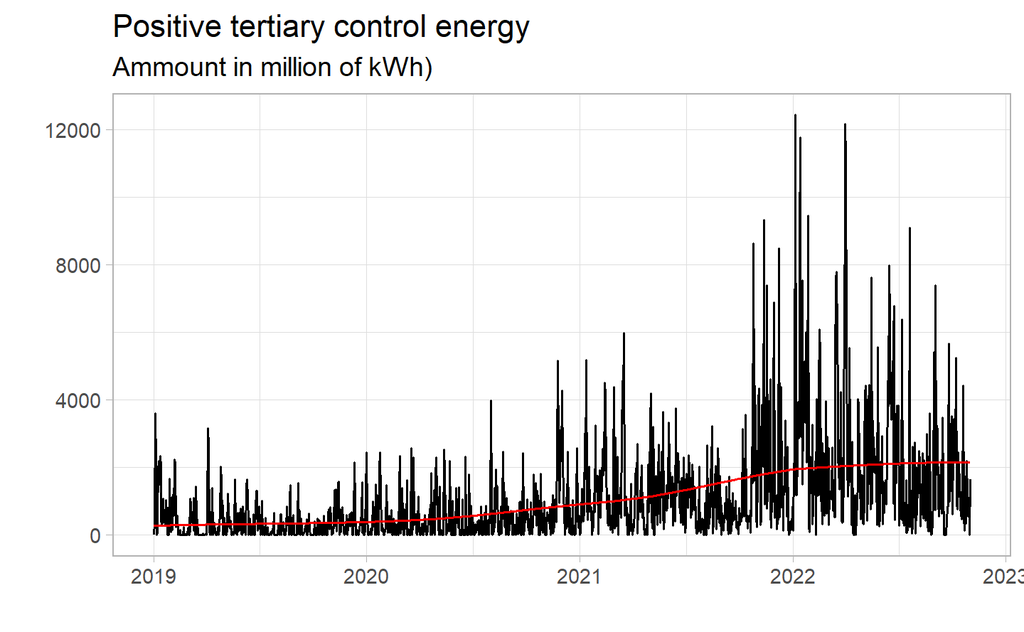

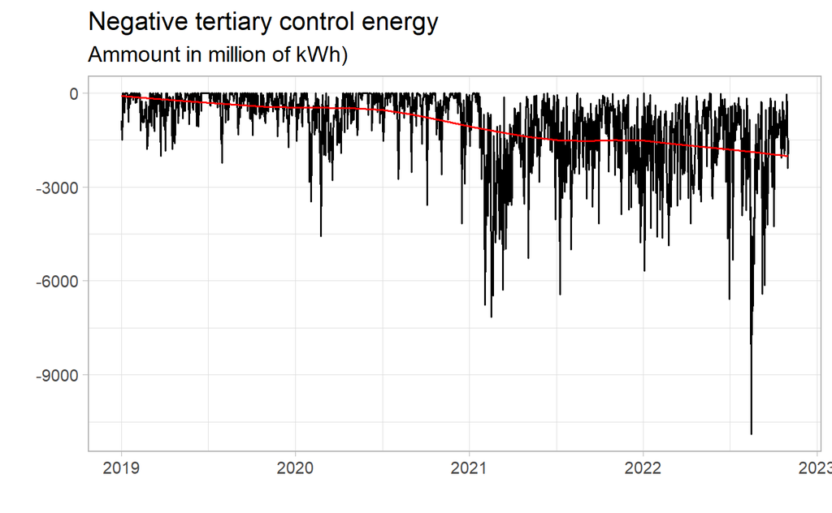

# 5 Different level of aggregation

## 5.1 Overall

## 5.2 Border

## 5.3 Foreign

## 5.4 Canton

Let’s do the same for Cantons : -> Where is the electricity consumed and where does it come from ? -> what drives it ? density, mapping, policy, mapp of barrage/hydrolyique central, plant and so on

What data do we have :

All the different cantons where set as variable (horizontal), in order to perform the anaylsis we needed to transform our Data-set in a vertical shape.

Here is what the final version look like (we only show 1 variable for the Time)

| time | Cantons | production | consumption |
| --- | --- | --- | --- |
| 2015-01-01 00:15:00 | argovie | 511742 | 151008 |
| 2015-01-01 00:15:00 | fribourg | 6657 | 82368 |
| 2015-01-01 00:15:00 | glaris | 56449 | 12761 |
| 2015-01-01 00:15:00 | grisons | 196507 | 89631 |
| 2015-01-01 00:15:00 | lucerne | 4576 | 104484 |

-> We have, for each 15-minute period, the consumption and production of each Cantons. As said in introduction, some Cantons have been grouped together. You can see the breakdown here:

```
#>  [1] "argovie"       "fribourg"      "glaris"        "grisons"
#>  [5] "lucerne"       "neuchatel"     "soleure"       "saint_gall"
#>  [9] "tessin"        "thurgovie"     "valais"        "appenzell"
#> [13] "bale"          "berne_jura"    "schwytz_zoug"  "obw_nidw_uri"
#> [17] "geneve_vaud"   "schaff_zurich"
```

24 Cantons (do not differentiate half-canton) spread over 18 values. -> For further analysis, we will split the value to get the 24 cantons. Method and results will be presented in an other section.

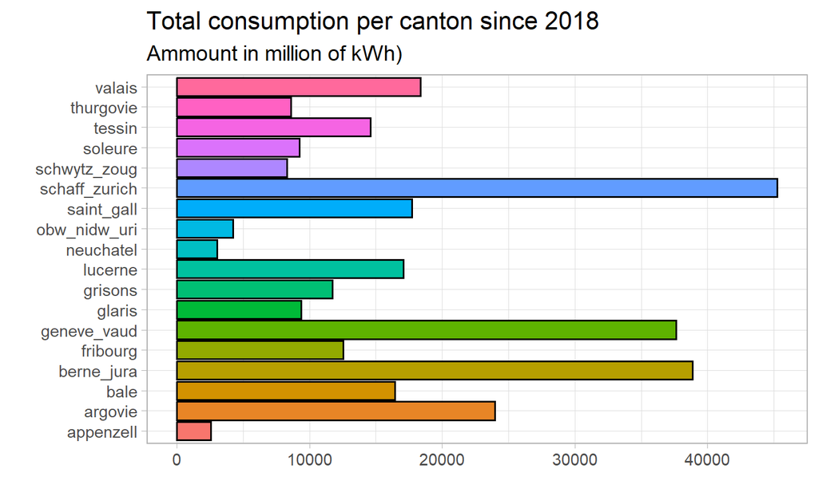

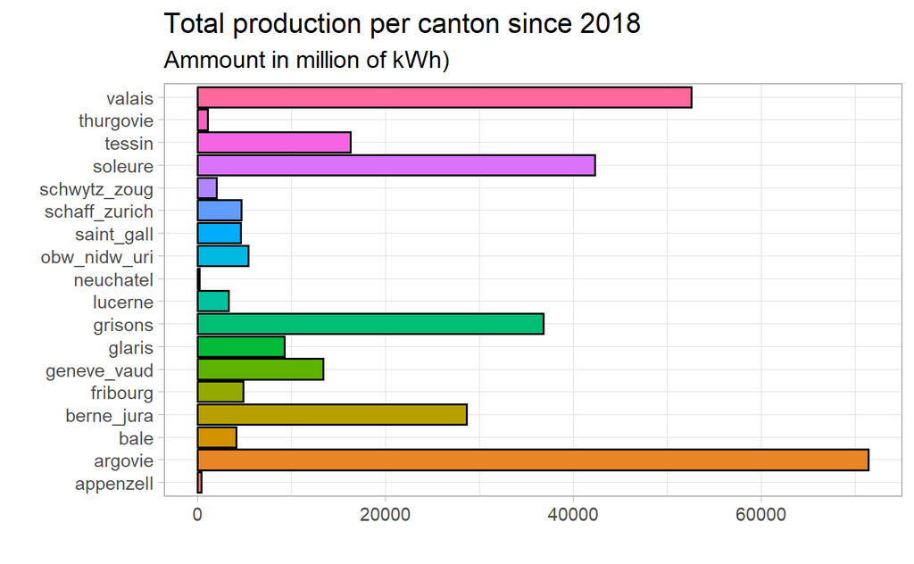

Many difference here : Higher standard deviation for production Consumption and Production seems independent -> not driven by the same variable

Let’s see the monthly seasonality and trends over time for the top 3 of each category :

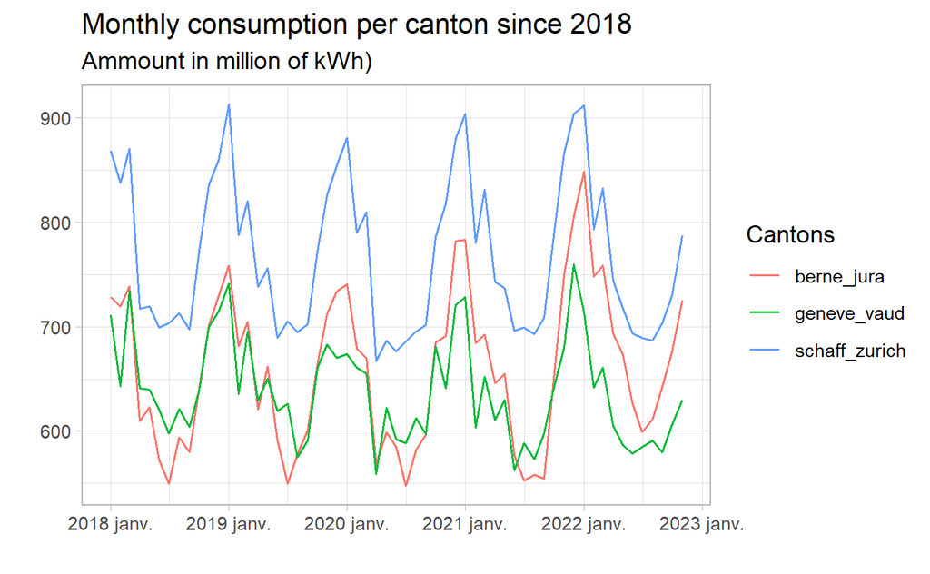

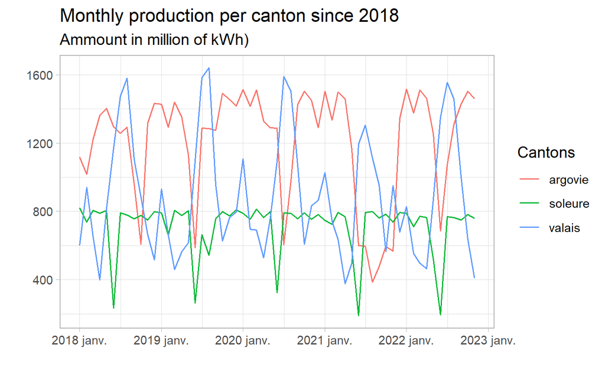

STL decomp for top 3 prod and top 3 cons

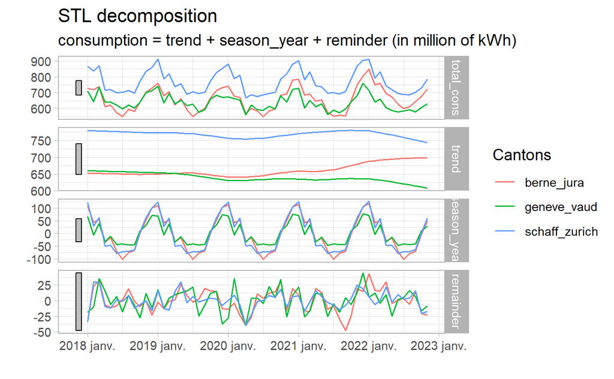

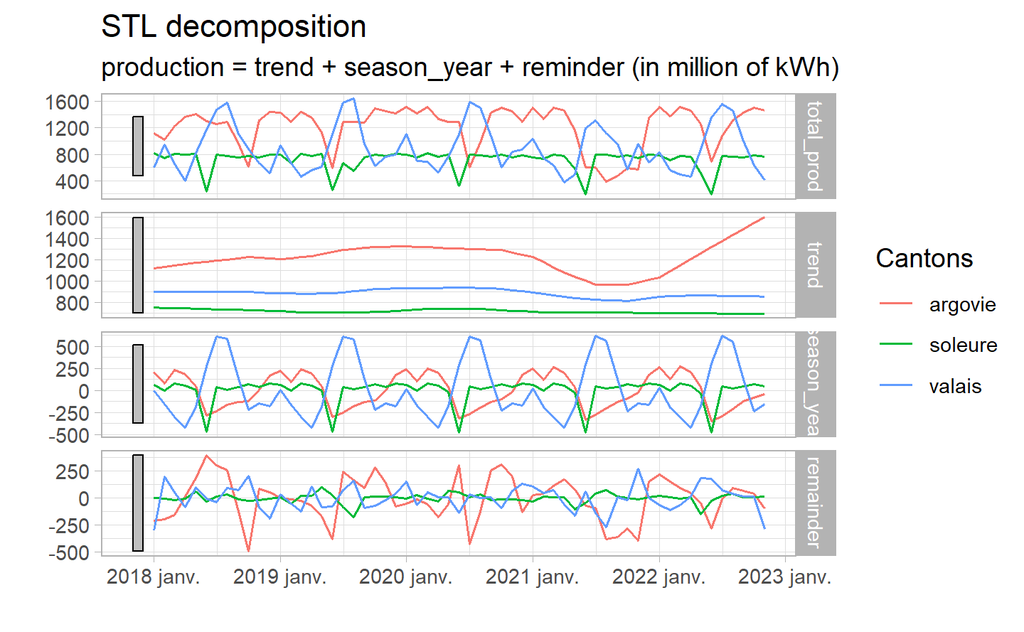

Facet wrap per Cantons with and without free scale :

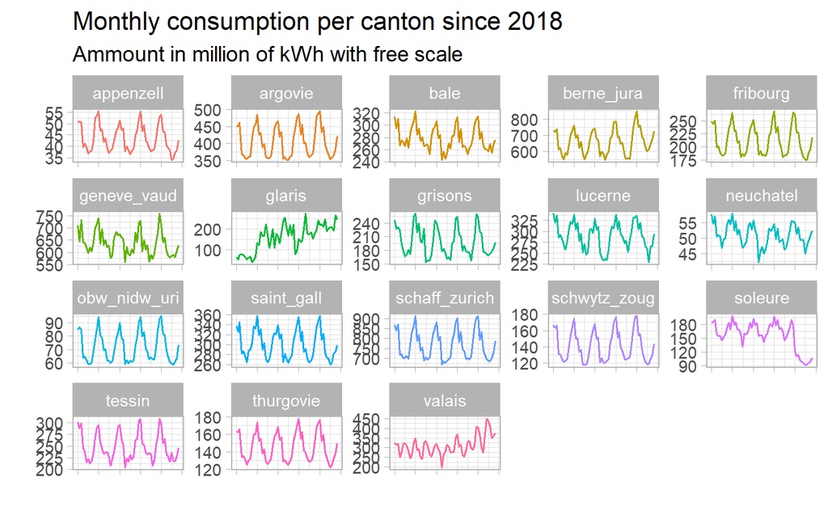

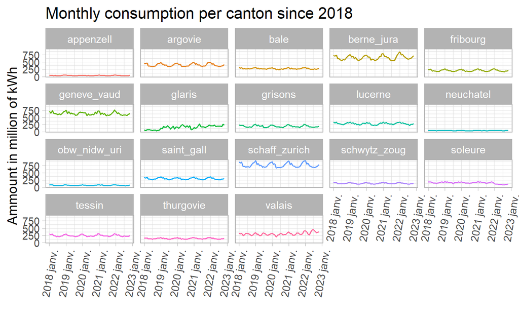

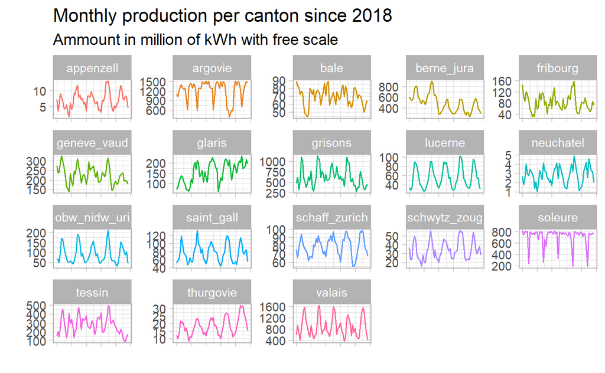

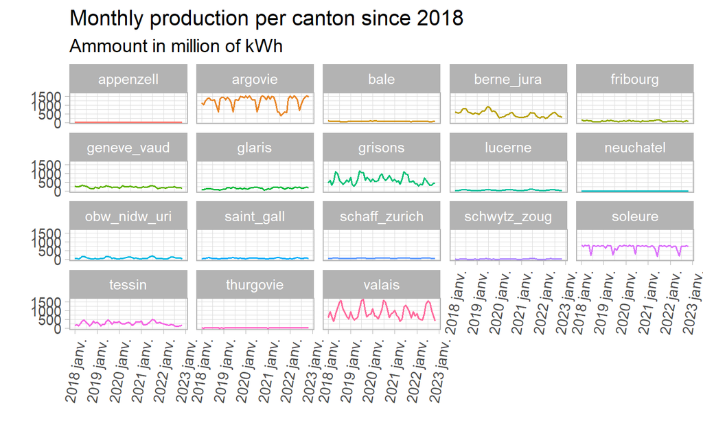

Features analysis to check the strength of the seasonality/trend

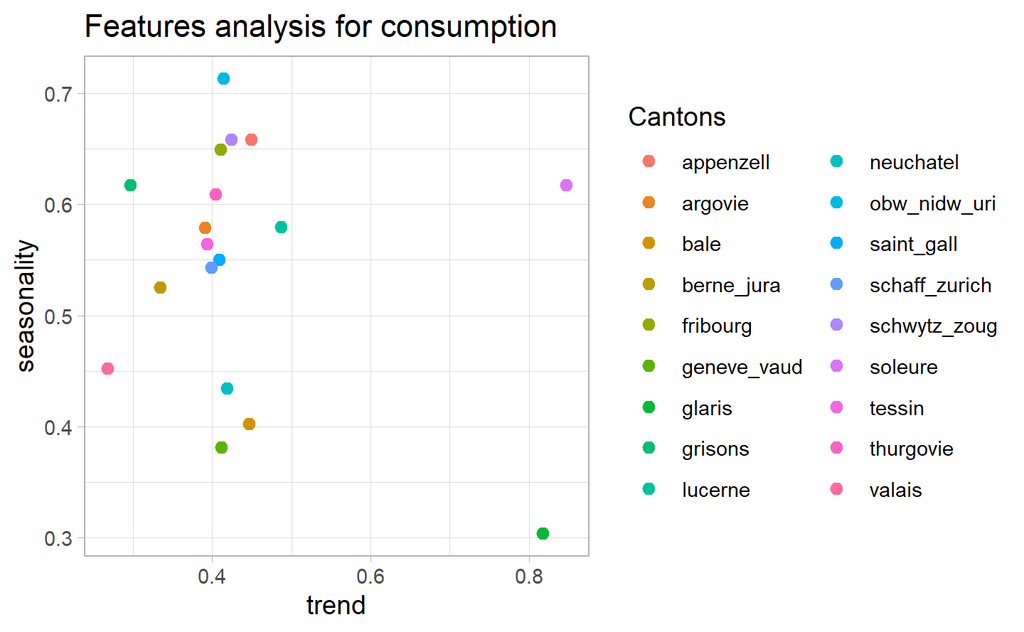

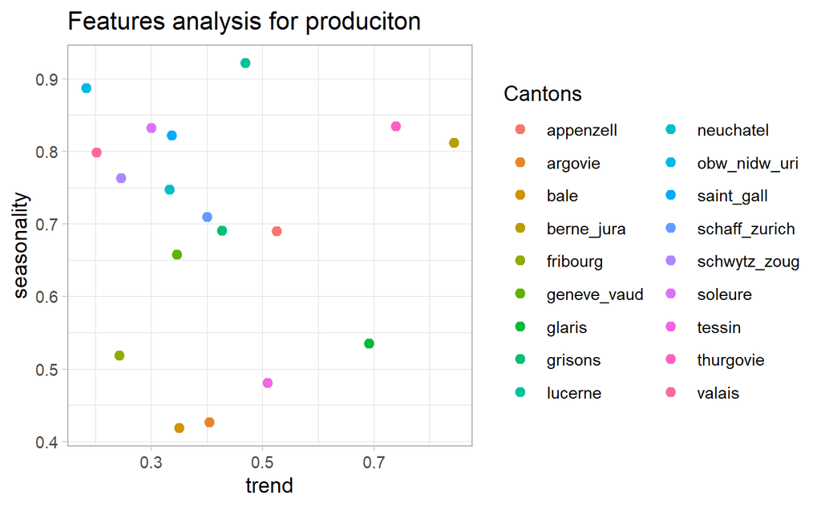